# Regressions and Identification

Data Analytics for Finance

Caspar David Peter

peter@rsm.nl

Rotterdam School of Management, Accounting Department

# Regressions and Identification

## Regressions and Identification

### Today’s Journey

- Identification: What it means and why it matters
- The identification problem: Endogeneity
  - Selection bias
  - Omitted variable bias
- DiLLMa: seeing the problem in action
- The gold standard: Experiments
- Ordinary Least Squares (OLS) regression

### Literature

- Huntington-Klein (2022) (Chapters 5 & 13)
- Verbeek (2021) (Chapters 2.1)

## Regressions and Identification

### Recap - Where did we leave things?

#### Last time: The Research Pipeline

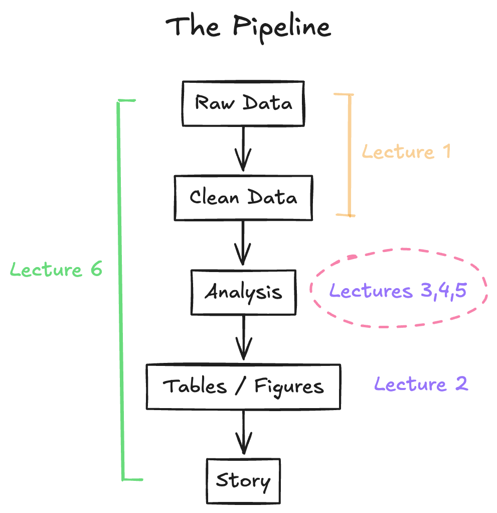

#### Raw & Clean Data, Visualization

- From messy to tidy data
- Exploratory data analysis with focus on visualization

##### Today’s Menu

- Identification & OLS regression
- Experiments
- DiLLMa (example)

## Regressions and Identification

### Learning Objectives

#### By the end of today, you will be able to

- Understand the concept of identification in causal inference
- Recognize endogeneity issues such as selection bias and omitted variable bias
- Explain the importance of random assignment in experiments
- Describe the basics of Ordinary Least Squares (OLS) regression
- Interpret OLS regression output and understand when estimates are trustworthy

**Hands-on Practice**

In Assignment 3, you’ll apply these concepts: run OLS regressions, test assumptions, and create publication-quality tables.

## Regressions and Identification

### Introduction to Identification

#### Key concepts

| Concept | Meaning | Example |
| --- | --- | --- |
| **Data‑Generating Process (DGP)** | The complete set of rules that determine how the data you observe are created | Newton’s law of gravity |
| **Variation** | The differences in a variable’s value across observations. | How people’s incomes differ by hair color across individuals. |
| **Identification** | The process of ensuring that the variation you exploit is causal, not a spurious alternative | Chocolate consumption and Nobel laureates (this is spurious) |

## Identification

### Why is identification important?

Identification is the bridge between:

1. Theory / prior knowledge (what we already know about the DGP)
2. Data (what we observe)
3. Causal or associational conclusions that are scientifically defensible

## Identification

### What is identification?

#### Definition

- Identification refers to the process of determining the specific variation in data that answers a research question
- It involves isolating the part of the data that reflects the causal relationship of interest

#### Example

- Estimating the effect of LLM use on exam scores<sup>1</sup>
- Need to *isolate variation* in LLM use that is not confounded by other factors (e.g., student ability)
[^1]: For an alternative example see Huntington-Klein (2022) (Chapter 5)

## Identification

### What are the ingredients for identification?

#### Key Assumptions

##### Data Generating Process (DGP)

Assumes that observations are produced by underlying laws or processes

##### Theory and Assumptions

Used to identify which parts of the DGP explain the data and refine research designs

##### Limiting Explanation

Assumptions help block non-essential variations, focusing on the aspect of data that aligns with the research question.

## Identification

### Key Assumptions in DGP and Identification

##### Known & Unknown

Part of DGP is understood (helps form assumptions); part is unknown (area of exploration)

##### Theoretical Framework

Research relies on known aspects of DGP to interpret data and identify genuine causal effects

##### Identification Strategy

Techniques like controlling for variables, subgroup analyses, or hypothetical scenarios help test specific segments of DGP

##### Assumption-Based Progress

Continued research and empirical testing refine and validate assumptions about parts of the DGP

# The Identification Problem: Endogeneity

## Endogeneity

### What can go wrong?

When we try to estimate causal effects, we face a fundamental challenge:

> Endogeneity occurs when the explanatory variable (X) is correlated with the error term (ε) in our model.

This correlation can arise from several sources… let’s focus on two of the most common<sup>1</sup>

Mathematically: $\text{Cov}(X, \varepsilon) \neq 0$

[^2]: Other sources include measurement error and simultaneity (X causes Y and Y causes X -> Think: Police and Crime rates).

## Endogeneity

### Source 1: Selection Bias

#### Definition

Selection bias occurs when individuals self-select into treatment based on characteristics that also affect the outcome.

#### The problem

- People who choose to do X are systematically different from those who don’t
- These differences—not X itself—may explain the outcome

#### Classic examples

- Do hospitals make people healthier? (Sick people go to hospitals)
- Does college increase earnings? (High-ability students attend college)
- Do LLMs improve exam scores? (Tech-savvy students use LLMs)

## Endogeneity

### Source 2: Omitted Variable Bias (OVB)

#### Definition

Omitted variable bias occurs when a relevant variable that affects both the explanatory variable (X) and the outcome (Y) is left out of the analysis.

#### The problem

- The omitted variable confounds the relationship
- We attribute its effect to X, biasing our estimate

#### Formal condition for OVB

A variable Z causes OVB if:

1. Z affects Y (Z → Y)
2. Z is correlated with X (Z ↔︎ X)
3. Z is not included in the model

**The connection**

Selection bias is one cause of OVB. When people self-select based on characteristic Z (which also affects Y), and we omit Z from our model, we have OVB.

## Endogeneity

### Visualizing the Problem

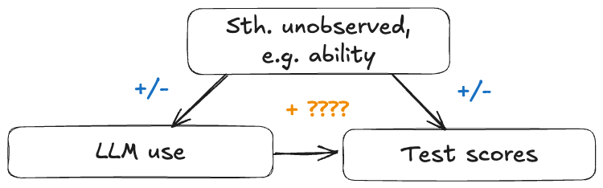

**Key insight**

If ability affects both LLM use and exam scores, any naive comparison of LLM users vs. non-users will be confounded.

## Endogeneity

### Why does this matter?

#### The consequence

Endogeneity can:

- Inflate the estimated effect (make X look better than it is)
- Deflate the estimated effect (make X look worse than it is)
- Flip the sign of the estimated effect (make X look beneficial when it’s harmful, or vice versa)

#### The challenge

We often cannot directly observe the confounding variables!

> Let’s see this problem in action with a concrete example…

# Large Language Models (LLMs) & Exam Scores (DiLLMa)

**Disclaimer**

I created this example (incl. the data) for educational purposes only. It does not represent real individuals or actual events.

## “DiLLMa”

### What’s the story?

#### Motivation

- LLMs are increasingly used by students e.g. for exam preparation
- There is a debate about whether LLM use improves or hinders learning outcomes
- Understanding the causal effect of LLM use on exam scores is crucial for educators and policymakers

#### Identification challenge

- We have observational data on students’ LLM use and their exam scores
- We need to identify the causal effect of LLM use on exam scores, accounting for potential confounders like student ability, study habits, and demographics

**Research question**

What is the effect of LLM use on students’ exam scores?

Libby Boxes

# Let’s go!

[figure not shown]

## “DiLLMa”

### What could possibly go wrong?

#### Naive comparison

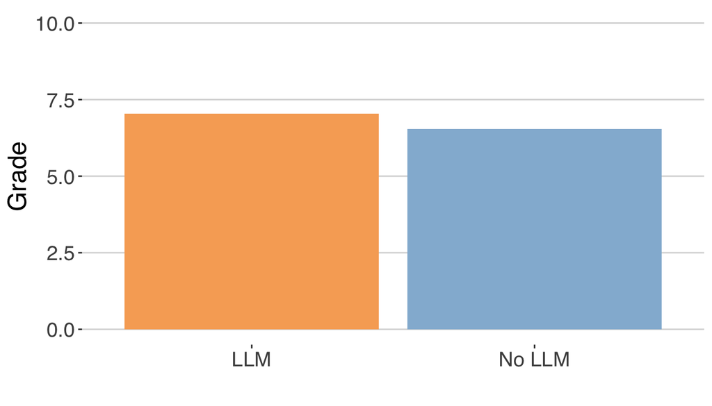

#### What do we find?

- Students who used LLMs scored higher on average
- Naive comparison suggests a positive effect of LLM use on exam scores
- Economic effect: ~0.5 point increase in exam scores

**But…**

Is this effect causal? Or are there confounding factors at play?

## DiLLMa

### Step 2: Looking at Observable Characteristics

#### Variables in the dataset

| Variable | LLM | No LLM | Difference | t-stat. | p-value |
| --- | --- | --- | --- | --- | --- |
| Exam score | 7.04 | 6.55 | 0.50 | -5.99 | 0.00 |
| Attendance rate | 74.15 | 75.43 | -1.28 | 1.42 | 0.15 |
| Female | 0.49 | 0.50 | -0.01 | 0.39 | 0.70 |
| Age | 21.37 | 21.34 | 0.03 | -0.18 | 0.86 |
| Study hours | 20.09 | 20.34 | -0.25 | 0.35 | 0.73 |

#### “Eye test”

- The LLM group has a higher average exam scores
- The groups are comparable on observable characteristics, on average<sup>1</sup>
- However, there may be unobservable factors (e.g., innate ability, motivation) that differ between the groups and affect exam scores

What is a t-test

[^3]: The gender variable is coded as 1 if the subject identifies as female, and 0 otherwise.

# What unobservable factors could play a role?

Do you have any ideas? What could be part of the data generating process that we do not observe in the data?

## Think about it for a moment…

[figure not shown]

## DiLLMa

### Step 3: What about ability?

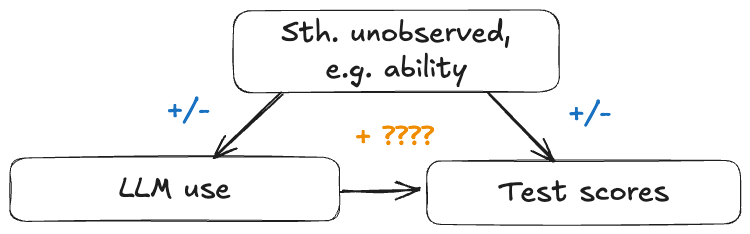

What happens if we could observe and condition on (or control for) ability?

Now, it comes in handy that I created the data myself and we can actually observe ability!

## DiLLMa

### Step 4: The Reveal

#### Controlling for ability<sup>1</sup>

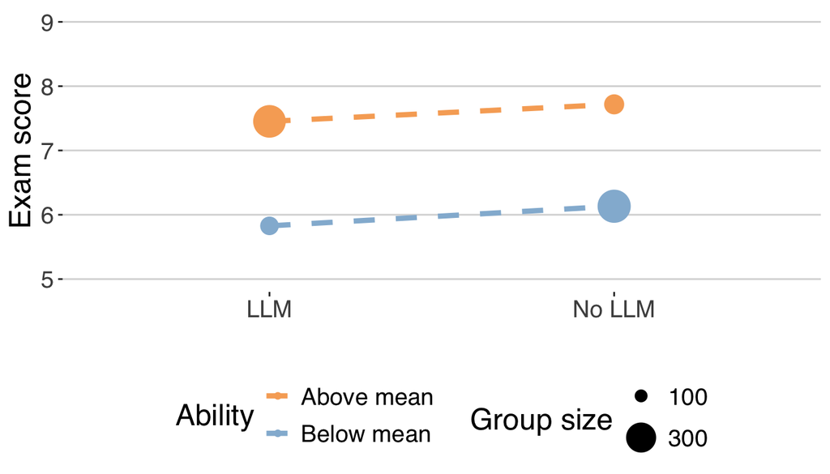

## Do unobservable factors play a role?

### Let’s dissect the results

#### Conditional means: -0.31 to -0.26

| Group | LLM | No LLM | Difference |
| --- | --- | --- | --- |
| Low ability | 5.83 | 6.13 | -0.31 |
| High ability | 7.45 | 7.72 | -0.26 |

#### Group composition

| Group | LLM | No LLM | Difference |
| --- | --- | --- | --- |
| Low ability | 122 | 379 | -257 |
| High ability | 364 | 135 | 229 |

**Key insight**

- Within high-ability students: LLM users do worse
- Within low-ability students: LLM users do worse

## Do unobservable factors play a role?

### Let’s dissect the results

#### Unconditional means

$$\text{LLM users: }\frac{122 \times 5.83 + 364 \times 7.45}{486} \approx 7.04$$
$$\text{Non-users: }\frac{379 \times 6.13 + 135 \times 7.72}{514} \approx 6.55$$

#### Naive effect: +0.49 (positive!)

> LLMs hurt everyone — we were just fooled by who chose to use them.

# What did we just discover?

## What did we just discover?

### Recap of findings

#### Results summary

1. Naive test: positive effect → “LLMs improve grades!”
2. Add ability control: effect flips negative → “Wait, no they don’t”
3. Conditional means plot: the reveal—LLMs hurt everyone, we were just fooled by who chooses to use them

#### Key insight

**This is Selection Bias**

The groups differed systematically on ability. High-ability students selected into LLM use — and they would have done well anyway.

# Connecting the Dots: This is Endogeneity!

## DiLLMa

### What we just witnessed

#### The pattern

| Analysis | LLM Coefficient | Interpretation |
| --- | --- | --- |
| Naive comparison | **Positive** | LLMs help! |
| Control for ability | **Negative** | LLMs hurt! |

#### The explanation

This is a textbook case of selection bias manifesting as omitted variable bias:

1. Selection bias: High-ability students self-select into LLM use
2. OVB: When ability is omitted, its effect is attributed to LLM use
3. Result: The naive estimate is biased upward

**Key takeaway**

Naive comparisons can be misleading due to endogeneity issues like selection bias and OVB!

## DiLLMa

### The Sign-Flip Phenomenon

**Critical insight**

Omitted variable bias doesn’t just make estimates imprecise—it can completely flip the sign of your estimate!

#### In our example:

- True effect of LLM use: Negative (LLMs hurt learning)
- Naive estimate: Positive (because high-ability students use LLMs)
- Bias: Positive (ability is positively correlated with both LLM use and exam scores)

#### The formula (intuition):

$$\text{Naive estimate} = \text{True effect} + \text{Bias}$$
$$\text{Positive} = \text{Negative} + \text{(Large) Positive}$$

# What can we do about it?

## The gold standard: Experiments

### Why is randomization so important?

- *Controlling variation* in the causal variable, e.g. LLM use via random assignment
- Makes sure that the treatment and control group are similar along observable and *unobservable* dimensions
- The *only difference between the two groups is the treatment*
- This allows us to *attribute any difference in outcomes to the treatment*
- No selection bias (endogeneity issue)

Another term for Experiments is *Randomized Controlled Trials (RCTs)*.

## The gold standard: Experiments

### Designing and analyzing experiments

Types of experiments:

- Field experiments
  - aim to be as similar as possible to real-world decision situations
- A/B testing
  - aim to evaluate different versions of the same product
- *Lab experiments*
  - are carried out in an artificial environment, usually a computer lab

For more in-depth information on experiments and other causal inference methods, see Békés and Kézdi (2021).

## The gold standard: Experiments

### Setup of an experiment

- Random assignment of treatment via assignment rule
- Number of subjects? Ideally large, exact number via power analysis
  - *How many subjects do I need to detect a certain effect size?*
- Proportion of treated subjects? Ideally 50/50
- Covariate balance
  - Did random assignment work?

## The gold standard: Experiments

### DiLLMa experiment

- Randomly assign students to LLM use or no LLM use
- Ensure groups are balanced on observable characteristics (e.g., prior GPA, study habits)
- Measure exam scores after the treatment period
- Analyze the difference in exam scores between the treatment and control groups

## The gold standard: Experiments

### DiLLMa experiment

#### Random assignment of LLM use

#### Naive comparison

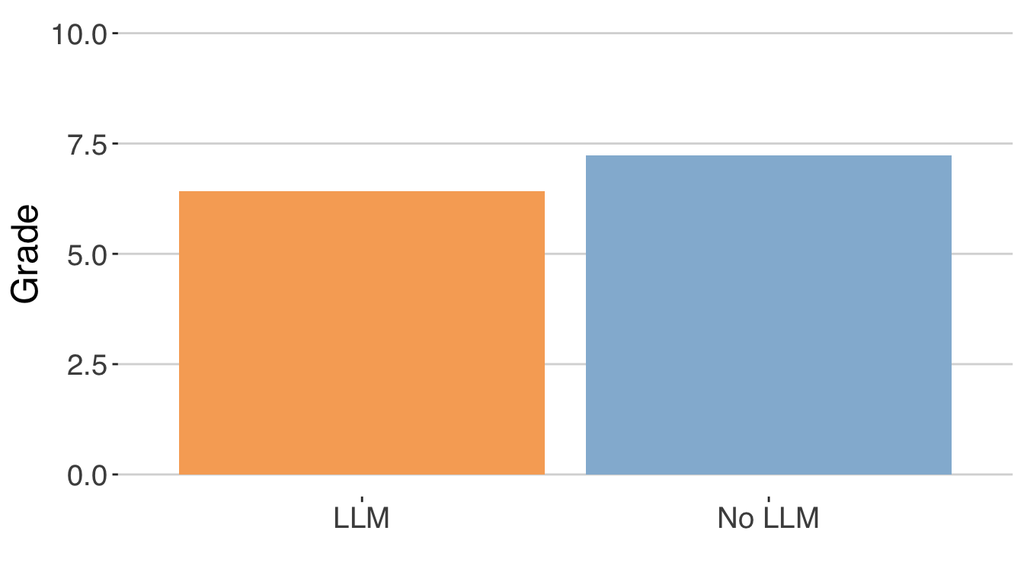

**But…**

Did random assignment work? Are the groups balanced on observable & unobservable characteristics?

## The gold standard: Experiments

### DiLLMa experiment

#### Covariate balance check

| Variable | LLM | No LLM | Difference | t-stat. | p-value |
| --- | --- | --- | --- | --- | --- |
| Exam score | 6.43 | 7.22 | -0.80 | 8.75 | 0.00 |
| Attendance rate | 74.62 | 75.01 | -0.39 | 0.43 | 0.66 |
| Female | 0.49 | 0.49 | 0.00 | -0.02 | 0.98 |
| Age | 21.29 | 21.43 | -0.13 | 0.91 | 0.36 |
| Study hours | 19.92 | 20.56 | -0.64 | 0.89 | 0.37 |
| Ability | 0.01 | 0.03 | -0.02 | 0.33 | 0.74 |

## The gold standard: Experiments

### Takeaways

- Random assignment assures that effect is not due to *selection bias*
- In the experiment you control…
  - who receives the treatment (the treatment group),…
  - and who doesn’t (the control group)
- You can control other aspects of the situation to avoid other confounders
- You can measure the effect of the treatment on the outcome
- Potential trade-off between internal and external validity

# What to do if controlling random assignment is not possible?

## What to do if controlling random assignment is not possible?

### Reality check

#### The reality of finance research

- Most financial phenomena cannot be experimentally manipulated
- We rely on observational data
- Need tools to make the best of imperfect situations

#### Two approaches

##### OLS with controls (today)

- Add observable confounders as control variables
- Limited: can’t control for unobservables

##### Quasi-experimental methods (Lecture 4)

- Exploit natural variation
- Difference-in-Differences, etc.

# Ordinary Least Squares (OLS)

## Ordinary Least Squares (OLS)

### The Skinny

#### What is OLS regression?

- OLS is the workhorse of explanatory analytics
- It lets us answer “What would happen to the expected value of $Y$ if we changed $X$ by one unit?”

#### Prediction vs explanation

- Prediction: use $X$ to forecast $Y$
- Statistical explanation: describe the relationship between them via a functional form such as
  $$Y = \beta_0 + \beta_1 X + \varepsilon.$$
- The coefficient $\beta_1$ is the slope — a one‑unit change in $X$ is associated with a $\beta_1$ change in $Y$.

## Ordinary Least Squares (OLS)

### The Skinny

#### Choosing a shape for the relationship

Linear:
$$Y = \beta_0 + \beta_1 X.$$

“Linear‑in‑parameters” (e.g., quadratic):
$$Y = \beta_0 + \beta_1 X + \beta_2 X^2.$$

#### Added variables and control (multi‑predictor/multiviriate OLS)

$$Y = \beta_0 + \beta_1 X + \beta_2 Z + \varepsilon,$$
the coefficient on $X$ is estimated using only the variation in $X$ that is left after regressing $Z$ out of both $X$ and $Y$ — that is, you “control for” $Z$.

There are also non‑linear models: logit, probit, poisson, etc.

## Ordinary Least Squares (OLS)

### The Skinny

#### When does it work perfectly (OLS Assumptions)?

| Assumption | What it requires | Role |
| --- | --- | --- |
| Linearity | $E[Y \mid X] = \beta_0 + \beta_1 X$ | Correct specification of functional form |
| Exogeneity | $E[\varepsilon \mid X] = 0$ | Ensures $\hat{\beta}$ is unbiased and consistent |
| Homoscedasticity | $Var(\varepsilon \mid X) = \sigma^2$ | Standard errors are efficient and unbiased |
| Independence | Observations are i.i.d. | Standard error formulas are valid |
| Normality (small samples) | $\varepsilon \sim N(0, \sigma^2)$ | Validates t-tests and confidence intervals |

## Ordinary Least Squares (OLS)

### The Skinny - For those who prefer plain English

#### When does it work perfectly (OLS Assumptions)?

| Assumption | Plain English |
| --- | --- |
| Linearity | The relationship between X and Y is a straight line |
| Exogeneity | X is not correlated with anything else that affects Y |
| Homoscedasticity | The spread of errors is the same across all values of X |
| Independence | One observation doesn’t influence another |
| Normality (small samples) | Errors follow a bell curve—only matters for hypothesis testing with few observations |

## Ordinary Least Squares (OLS)

### The Skinny

#### What if assumptions are violated?

| Assumption | If violated | How to check |
| --- | --- | --- |
| Linearity | Estimates are biased; wrong model | Plot residuals vs fitted values |
| Exogeneity | Estimates are biased and inconsistent | Theory and DAGs; no direct test |
| Homoscedasticity | Standard errors are wrong (often too small) | Plot residuals vs fitted; Breusch-Pagan test |
| Independence | Standard errors are wrong | Durbin-Watson test; check data structure |
| Normality | t-tests and CIs invalid in small samples | Q-Q plot of residuals |

## Ordinary Least Squares (OLS)

### The Skinny

#### What else could go wrong?

| Issue | If present | How to check |
| --- | --- | --- |
| Multicollinearity | Estimates unbiased but imprecise; unstable coefficients | Correlation matrix; VIF > 10 |
| Outliers | Single observations can distort estimates | Summary stats; plots |
| Measurement error in X <sup>1</sup> | Coefficient biased toward zero (attenuation bias) | Theory; compare multiple measures if available |
| Small sample size | Estimates imprecise; normality assumption matters more | Check n relative to number of predictors |
| Missing data | Bias if not missing completely at random | Check patterns; compare complete vs incomplete cases |

[^5]: Measurement error in X becomes an edogeneity issue when correlated with $\epsilon$. Measurement error in Y increases variance but does not bias coefficients.

## Ordinary Least Squares (OLS)

### What does it look like?

#### Plot

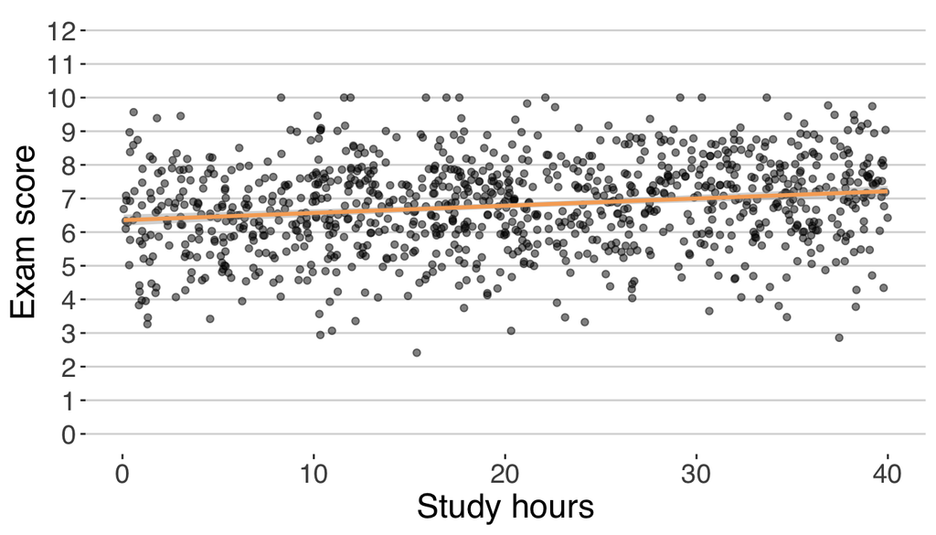

#### Table output

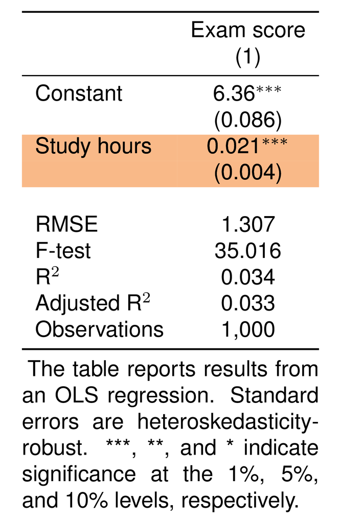

## Ordinary Least Squares (OLS)

### What does the output tell me?

| Component | Meaning | Typical notation |
| --- | --- | --- |
| Rows (Coefficient, Standard Error) | Estimate of $\beta_j$ and its SE (or t‑stat) | `0.021 (0.004)` |
| Significance stars | Indicates p‑value thresholds | `***` = p < .01 |
| $R^2$ | Proportion of variance in $Y$ explained by the model | 0.034 |
| Adjusted $R^2$ | Corrects $R^2$ for number of predictors | 0.033 |
| F‑statistic | Joint test that all non‑constant coefficients equal zero | 35.016 |
| RMSE | Standard deviation of residuals (or “root mean squared error”) | 1.307 |

## Ordinary Least Squares (OLS)

### How to interpret the output?

#### Table output

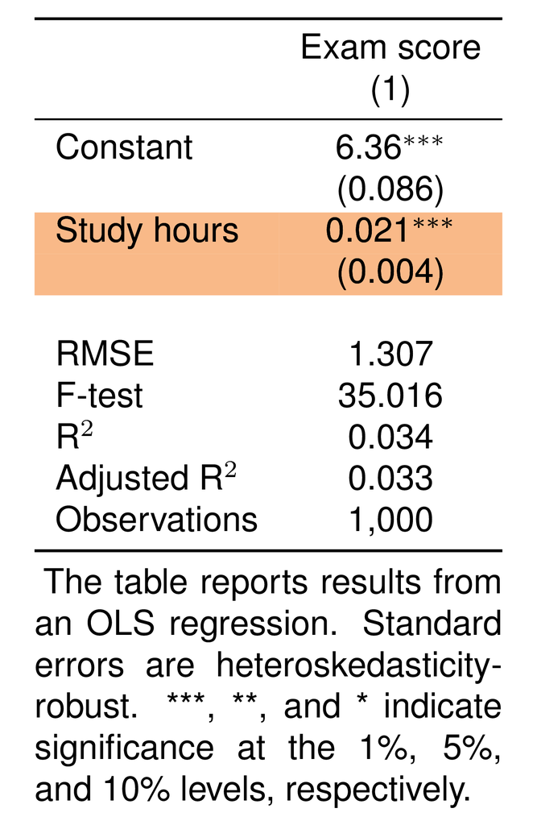

#### Interpretation

Precision: Given SE=0.004, even small differences in coefficients are detectable

Significance: `***` indicates the coefficient differs from zero at the 1% level

t-stat: The slope is about 5 standard errors away from zero (0.021/0.004 = 5), indicating strong evidence against the null hypothesis of no effect

Typically, we focus on the coefficient estimates, their precision (SEs), and significance levels to interpret OLS results.

## Ordinary Least Squares (OLS)

### Takeaways

- The error term separates what is explained by the predictors from everything else
- Exogeneity is the linchpin that turns OLS estimates into unbiased causal indicators
- Sampling variability is quantified by standard errors, which underpin hypothesis tests, p‑values, and confidence intervals
- Regression tables encapsulate all of this: coefficients, precision, significance, model‑fit metrics

# OLS DiLLMa: Putting It All Together

## OLS DiLLMa

### DiLLMa OLS results

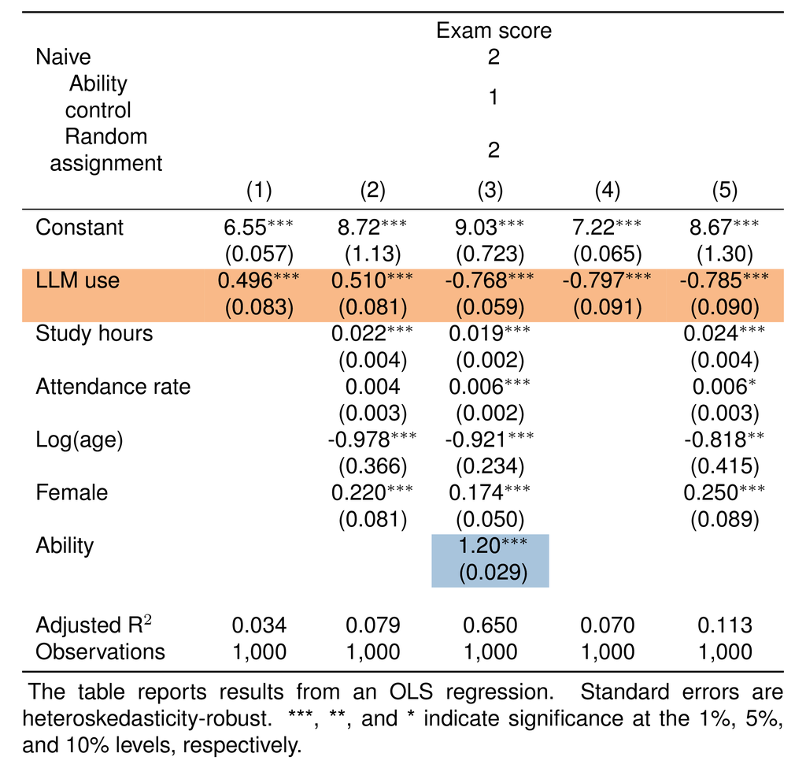

## OLS DiLLMa

### DiLLMa OLS results

#### Prior findings recap

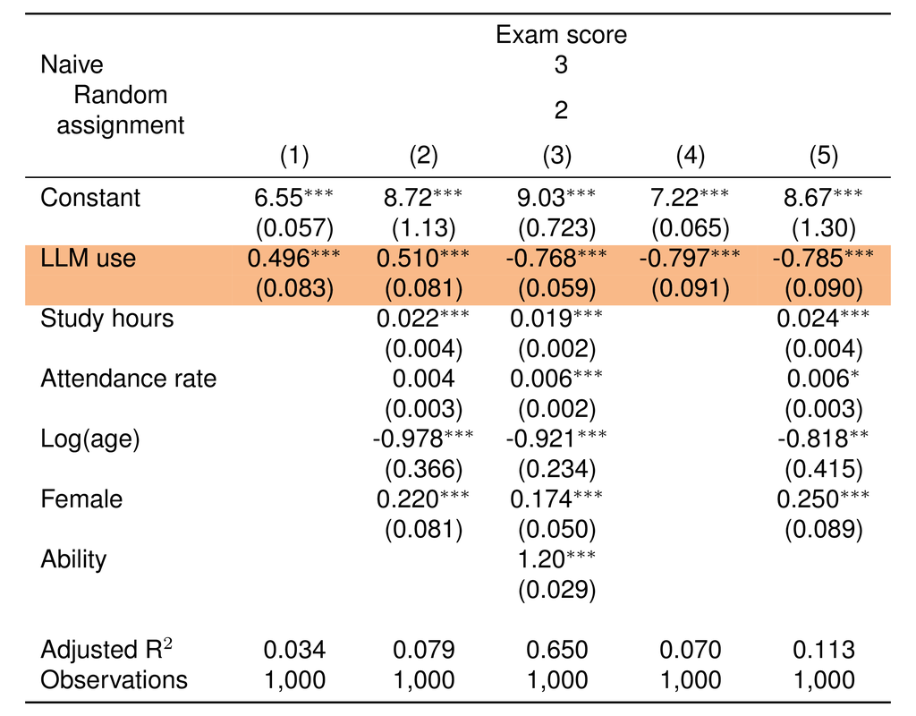

#### Reconciling OLS with comparison of means

- The coefficient on `llm` in the naive OLS regression is equivalent to the difference in means between LLM users and non-users
- Adding controls adjusts for confounding variables, changing the estimated effect of LLM use on exam scores
- Including `ability` further refines the estimate by accounting for this key confounder and gives us the “true” effect of LLM use
- Random assignment eliminates confounding, so the naive estimate from the randomized data reflects the causal effect of LLM use on exam scores
- In an OLS setting we refer to the *selection bias* issue as *omitted variable bias (OVB)*

## OLS DiLLMa

### The Limits of “Controlling For”

**Important caveat**

In DiLLMa, we could observe ability and control for it. In real research, we usually cannot observe all confounders.

#### The problem with observational data:

| What we did in DiLLMa | What happens in reality |
| --- | --- |
| Observed ability | Ability is unobserved |
| Controlled for it in OLS | Can’t control for what we don’t see |
| Got the “true” effect | Estimate remains biased |

#### The solution?

- Experiments (when possible)
- Quasi-experimental methods (when experiments aren’t possible) → Lecture 4

# Conclusion

## Conclusion

### Key takeaway

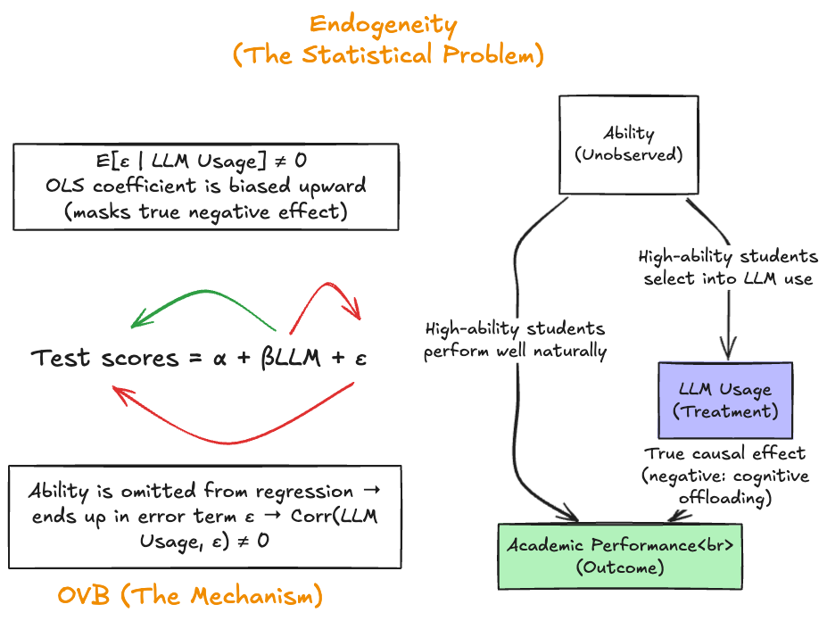

## Conclusion

### What we learned today

#### Identification

- Identification = isolating causal variation
- Endogeneity = X correlated with error term
- Two main sources: selection bias & OVB
- Can flip the sign of estimates!

#### Tools

- Experiments: Gold standard, but often infeasible
- OLS with controls: Works if you observe all confounders
- Next lecture: What if you can’t experiment AND can’t observe all confounders?

## Conclusion

### Looking Ahead

#### Coming up: Lecture 4 - Panel Data Methods

When we can’t run experiments AND controlling for observables isn’t enough, we need quasi-experimental methods:

- Difference-in-Differences (DiD)
- Exploits variation across groups AND time
- Can identify causal effects without experiments

We’ll continue the DiLLMa story with panel data!

Thank You for Your Attention!

See You in the Next One!

## References

Békés, Gábor, and Gábor Kézdi. 2021. *Data Analysis for Business, Economics, and Policy*. Cambridge University Press.

Huntington-Klein, Nick. 2022. *The Effect: An Introduction to Research Design and Causality*. 2nd ed. Chapman; Hall/CRC.

Verbeek, Marno. 2021. *Panel Methods for Finance: A Guide to Panel Data Econometrics for Financial Applications*. De Gruyter.

# Appendix

## Libby Boxes

### DiLLMa

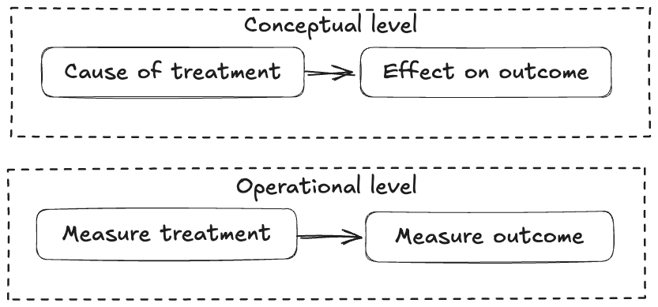

Back

## The gold standard: Experiments

### DiLLMa experiment

#### Covariate balance check - no random assignment!

| Variable | LLM | No LLM | Difference | t-stat. | p-value |
| --- | --- | --- | --- | --- | --- |
| Exam score | 7.04 | 6.55 | 0.50 | -5.99 | 0.00 |
| Attendance rate | 74.15 | 75.43 | -1.28 | 1.42 | 0.15 |
| Female | 0.49 | 0.50 | -0.01 | 0.39 | 0.70 |
| Age | 21.37 | 21.34 | 0.03 | -0.18 | 0.86 |
| Study hours | 20.09 | 20.34 | -0.25 | 0.35 | 0.73 |
| Ability | 0.56 | -0.50 | 1.07 | -20.11 | 0.00 |

## Theory, hypotheses, and operationalisation

### What is a hypothesis?

- A hypothesis is a **proposed explanation** for a phenomenon or a prediction of a possible causal correlation
- It is a tentative answer to a research question that guides the direction of study and investigation
- Its formulation is guided by existing (economic) **theory**
- A well-constructed hypothesis is **testable**, meaning it can be **supported** or **rejected** through experimentation

Back

## Theory, hypotheses, and operationalisation

### How do we test a hypothesis?

- Steps
- t-test
- Visual
- We need a baseline to test against: The null hypothesis ($H_0$)
- Why null? It states that there is no effect or no difference, which serves as a baseline assumption
  - $H_0$ is what you test your $H_1$ against, e.g. $H_0 = 0$
  - $H_1$ is the/your alternative hypothesis - what you might believe to be true
- A statistical test rejects $H_0$ if there is enough evidence against it
  - If we reject $H_0$, we accept $H_1$

The t-test measures how far the sample mean is away from $H_0$

Hypothesis:

- One-sided ($H_0 \leq 0$, $H_1>0$): $t = \frac{X-0}{SE(X)}$
- Two-sided ($H_0 = 0$, $H_1 \neq 0$): $t = \frac{X_{treated}-X_{control}}{SE(X_{treated}-X_{control})}$

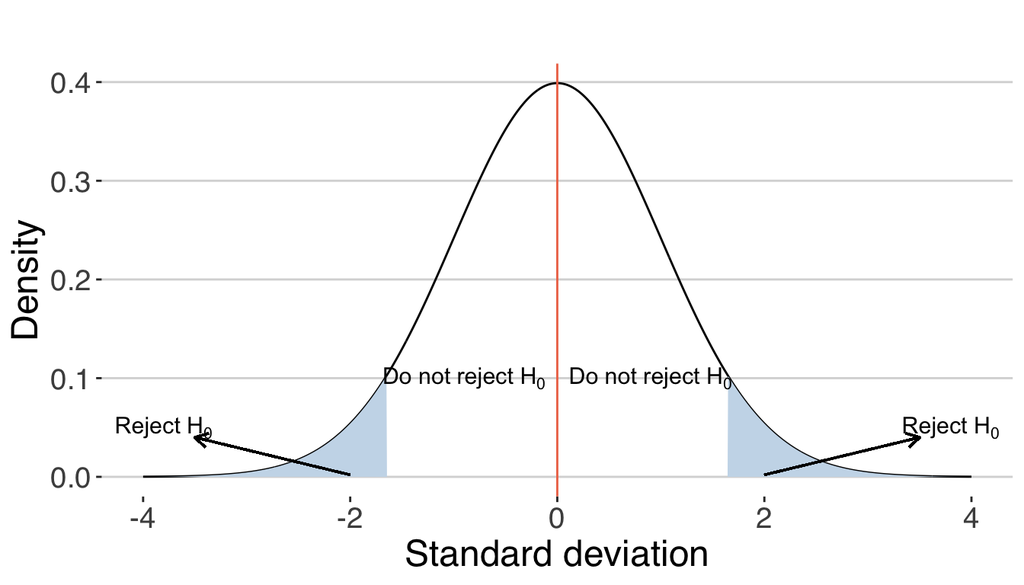